# ДЗ урока 6

## Казанцев Виталий

### 1 Задание (теорема сложения)

*Найти вероятность выпадения 2 или 5 очков при подбрасывании игральной кости, на гранях которой имеются соответственно 1,2,3,4,5 и 6 очков.*

### Ответ:

Пусть вероятность выпадения 2 A = 1/6, а вероятность выпадения 5 B = 1/6. Тогда вероятность выпадения A или B равна P = A + B = 1/6 + 1/6 = 1/3

```python
from fractions import Fraction

A = Fraction('1/6')
B = Fraction('1/6')
P = A + B
P
```

```
Fraction(1, 3)
```

### 2 Задание (теорема умножения)

*Найти вероятность того, что при двух подбрасываниях той же самой игральной кости сначала выпадет 2, а затем 5.*

### Ответ:

P = A*B = 1/6* 1/6 = 1/36

```python
P = A*B
P
```

```
Fraction(1, 36)
```

### 3 Задание

**Найти вероятность выпадения 2 и 5 очков при двух подбрасываниях той же самой игральной игральной кости. Обратите внимание на порядок выпадения костей!**

### Ответ:

Не совсем понял, чем эта задача отличется от второй. По всей видимости имеется ввиду варианты ввыпадения 2 и 2, или 2 и 5. или 5 и 5, или 5 и 2. Тогда P = AA + AB + BA + BB = 4/36 = 1/9

```python
P = A*A + A*B + B*A + B*B
P
```

```
Fraction(1, 9)
```

Если же имеется ввиду варианты 2 и 5, или 5 и 2, тогда P = AB + BA = 1/18

```python
P = A*B + B*A
P
```

```
Fraction(1, 18)
```

### 4 Задание (Геометрическая вероятность +интервалы)

*На отрезке AB длиной 20 см наугад отметили точку C. Какова вероятность, что она находится на расстоянии не более 9 см от точки А и не более 15 см от точки В?*

```python
import matplotlib
from matplotlib import pyplot as plt
%matplotlib inline
%config InllineBackend.figure_format='svg'
```

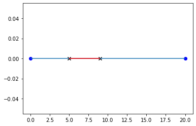

```python
plt.hlines(y=0, xmin=0, xmax=20)
plt.hlines(y=0, xmin=5, xmax=9, color='red')
plt.scatter(0,0, color='blue')
plt.scatter(20,0, color='blue')
plt.scatter(5,0, color='black', marker='x')
plt.scatter(9,0, color='black', marker='x')
```

Какова вероятность, что точка С попадет в красную область на графике? Длина красной области 4 см, а длина отрезка 20 см., тогда P = 4/20 = 1/5

### 5 Задание.

*Телефонный номер состоит из 7 цифр. Какова вероятность, что это номер 8882227?*

### Ответ:

Так как в задаче не сказано может ли номер начинаться с нуля или 9, то вероятность составления номера 8882227 составит P=1/10^7. Если же учесть общепринятые нормы, когда номер телефона не может начинаться с нуля или девятки, тогда вероятность составит P=1/8000000

### 6 Задание.

Набирая номер телефона, абонент забыл 2 последние цифры, и, помня только то, что эти цифры различны и среди них нет нуля, стал набирать их наудачу. Сколько вариантов ему надо перебрать, чтобы наверняка найти нужный номер? Какова вероятность того, что он угадает номер с первого раза?

### Ответ:

9x9 - 9 = 81 - 9 = 72

### 7 Задание** (необязательное)

*Чёрный куб покрасили снаружи белой краской, затем разрезали на 27 одинаковых маленьких кубиков и как попало сложили из них большой куб. С какой вероятностью все грани этого куба будут белыми?*

### Ответ:

Это белый кубик рубика. Получается 27 кубиков у каждого по 6 граней. Всего 162 грани. При этом 8 кубиков с тремя белыми гранями, 12 кубиков с двумя белыми гранями, 6 кубиков с одной белой гранью и один кубик полностью черный. Для каждого маленького кубика возможно 24 варианта установки при сборке большого кубика Получается ((8!х3^8)x(12!x2^12)x(6!x4^6)x24)/27!X24^27